# *Loss/Cost Functions*

## *What is Loss?*

*‘Loss’ helps us to understand how much the predicted value differ from actual value.*

*Function used to calculate the loss is called as **“Loss function”**.*

*Loss function is a method of evaluating “how well your algorithm models your dataset”. If your predictions are totally off, your loss function will output a higher number. If they’re pretty good, it’ll output a lower number. As you tune your algorithm to try and improve your model, your loss function will tell you if you’re improving or not.*

*“Loss functions are helpful to train a neural network.”*

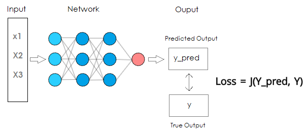

## *What’s the Difference between a Loss Function and a Cost Function?*

*Although cost function and loss function are synonymous and used interchangeably, they are different.*

*A **loss function** is for a **single training** example. It is also sometimes called an **error function**. A **cost function**, on the other hand, is the **average loss over the entire training dataset**. The **optimization strategies aim at minimizing the cost function**.*

## *Types of Loss Function*

- *Regression Loss Functions*
  - *Squared Error Loss*
  - *Absolute Error Loss*
  - *Huber Loss*
- *Binary Classification Loss Functions*
  - *Binary Cross-Entropy*
  - *Hinge Loss*
- *Multi-class Classification Loss Functions*
  - *Multi-class Cross Entropy Loss*
  - *Kullback Leibler Divergence Loss*

## *Regression Losses*

*Regression models deals with predicting a continuous value for example given floor area, number of rooms, size of rooms, predict the price of room.Loss function used in regression problem are called “Regression Loss Function”. Most used Regression loss function are below:*

### *Absolute Error Loss / Mean Absolute Error (MAE) / L1 Loss function / Least Absolute Deviations*

- *Mean absolute error, is measured as the average of **sum of absolute differences between predictions and actual observations**.*

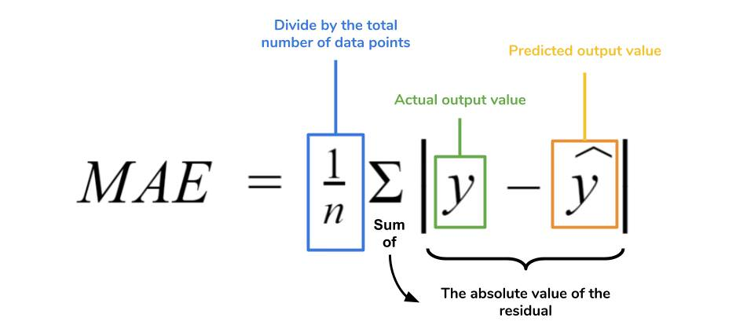

- *It measures the average “magnitude” of errors in a set of predictions, “without considering their “directions”.*
- *Robust to outlier.*
- *MAE output ranges between 0 and +inf.*
- *Derivatives of MAE are not continuous, making it inefficient to find the solution.*
- *MAE is also known as **“Least Absolute Deviations”** or “LAD”*

[figure not shown]

### *Mean Square Error (MSE) / L2 Loss function*

- *Mean Square error, is measured as the average of sum of squared differences between predictions and actual observations.*

[figure not shown]

- *It measures the average “magnitude” of errors in a set of predictions, “without considering their “directions”.*
- *Less robust to outliers.*
- *MSE loss is stable then MAE*
- *L2 loss output ranges between 0 and +inf.*
- *Derivatives of MSE are continuous, making it efficient to find the solution.*
- *“MSE is the most commonly used regression loss function”*

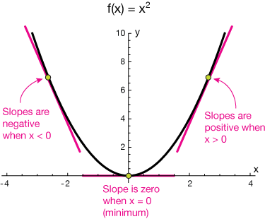

### *Huber Loss*

- *Huber loss is less sensitive to outliers in data than the squared error loss.*

[figure not shown]

- *This function is quadratic for small values of error /residual, and linear for large values.*
- *What is that small value for the error to make the function quadratic depends on the **“hyperparameter”, 𝛿 (delta)**, which can be tuned.*
- *Huber loss approaches MAE when 𝛿 ~ 0 and MSE when 𝛿 ~ ∞ (large numbers)*
- *Choice of delta is important because it decide what value you are willing set as an outlier.*
- *Error >delta (outlier cases)are minimized with L1 (Reason : Robust to outlier ), while error < delta (inlier cases) are minimized “appropriately” with L2.*
- *It is used in Robust Regression, M-estimation and Additive Modelling.*

[figure not shown]

*One big problem with using MAE for training of neural nets is its constantly large gradient, which can lead to missing minimal at the end of training using gradient descent. For MSE, gradient decreases as the loss gets close to its minimal, making it more precise.*

*Huber loss can be really helpful in such cases, as it curves around the minimal which decreases the gradient. And it’s more robust to outliers than MSE. Therefore, it combines good properties from both MSE and MAE. However, the problem with Huber loss is that we might need to train hyper-parameter delta which is an iterative process.*

*As said earlier that Huber loss has both MAE and MSE. So when we think **higher weightage should not be given to outliers**, go for Huber.*

```python
import numpy as np
import tensorflow as tf
import matplotlib.pyplot as plt
```

```python
x_guess = tf.lin_space(-1., 1., 100)
x_actual = tf.constant(0,dtype=tf.float32)
```

```python
l1_loss = tf.abs((x_guess-x_actual))
l2_loss = tf.square((x_guess-x_actual))
```

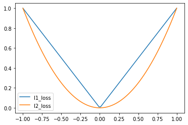

```python
with tf.Session() as sess:
    x_,l1_,l2_ = sess.run([x_guess, l1_loss, l2_loss])
    plt.plot(x_,l1_,label='l1_loss')
    plt.plot(x_,l2_,label='l2_loss')
    plt.legend()
    plt.show()
```

## *Binary Classification Loss Functions*

- *Binary classification is a prediction algorithm where the output can be either one of two items, indicated by 0 or 1*
- *Output of binary classification algorithms is a prediction score (mostly).*
- *So the classification happens based on the threshold the value (default value is 0.5).If the prediction score > threshold then 1 else 0.*

*Most used binary classification loss function are below:*

### *Binary Cross-Entropy or Log-loss error*

*What is Entropy(S)?*

*“Entropy is a measure of the randomness in the information being processed”*

*Mathematically, it is measured for a random variable X with probability distribution p(X) as follows*

[figure not shown]

*Reason for log in entropy* *: All events have the same probability(1/p) hence,it makes sense to use log(1/p) as a “measure of information”*

*Reason for negative sign* *:Entropy function use negative log(negative sign )to provide an easy metric for comparison. Reason for negative sign is that the positive log of numbers < 1 returns negative values, which is confusing to work with when comparing the performance of two models.*

*Since the probability value(p(x)) always lies between 0 and 1 function will return negative value.so by adding the negative sign value becomes positive.*

*Example : log(0.2) =-0.7 so to make it comparable do -log(0.2) = 0.7*

*Binary Cross-entropy loss, or log loss, measures the performance of a classification model whose output is a probability value between 0 and 1.*

*“In other terms , Binary Cross-entropy loss / log loss aims to reduce the entropy of the predicted probability distribution in binary classification problems”*

[figure not shown]

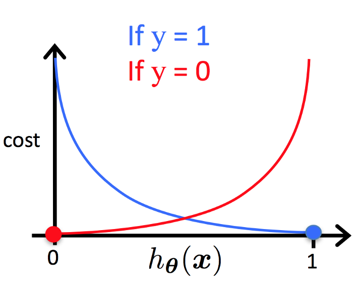

*The probability ( p/ Y pred) can be calculated using sigmoid function.*

*Why sigmoid function?* *The output value of sigmoid function ranges between 0 and 1. Hence this property make sigmoid function suitable for calculating the probability(p).*

### *Hinge Loss*

- *Hinge loss is most popular loss function during pre-deep learning era.*
- *Hinge loss is often used for binary classification problems.*
- *This type of loss is primarily used in SVM classifiers where the target values are in the set {-1, 1}.*

*When using hinge loss it is important to change the class label to -1 and +1.*

*Hinge Loss not only penalizes the wrong predictions but also the right predictions that are not confident.”*

- *Hinge loss output the value ranges from -inf to 1*
- *Hinge loss is used for **maximum-margin** classification,.*
- *Though hinge loss is not differentiable, it’s convex function which makes it easy to work with usual convex optimizers used in machine learning domain.*

[figure not shown]

## *Multi-class Classification Loss Function*

- *Multi-Class classification are those predictive modeling problems where there are more target variables/class.*
- *It is just the extension of binary classification problem.*

### *Multi-class Cross Entropy Loss*

**Most time,Multi-class Cross Entropy Loss is used as a loss function._**

*The generalised form of cross entropy loss is the multi-class cross entropy loss.*

*M — No of classes* *y — binary indicator (0 or 1) if class label c is the correct classification for input o* *p — predicted probability score of input o belonging to class c*

*The probability ( p o,c) can be calculated using softmax function.*

[figure not shown]

*J==>c (Class) and theta ==> o (inputs)*

**Why Softmax function?**

*Softmax implements a vector of ‘squashes’ k-dimensional real value to the [0,1] range of k-dimensional, while ensuring that the cumulative sum is 1.*

*“Softmax is implemented through a neural network layer just before the output layer. The Softmax layer must have the same number of nodes as the output layer.”*

[figure not shown]

_Specify the loss parameter as ‘**categorical_crossentropy**’ in the model.compile() statement_

### *Kullback-Liebler Divergence (KL-Divergence)*

*The Kullback-Liebler Divergence is a measure of how a probability distribution differs from another distribution. A KL-divergence of zero indicates that the distributions are identical.*

[figure not shown]

*KL Divergence is also know as “**Relative entropy**”.*

*Dkl(P||Q) is read as Divergence from Q to P.*

*The example below is discrete random function.*

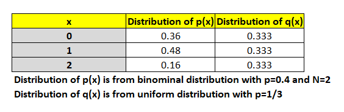

[figure not shown]

*Let solve this,*

[figure not shown]

*Applying values to the above formula,*

$$Dkl(P||Q) => 0.36 ln(0.36/0.333)+0.48 ln(0.48/0.333)+0.16 ln(0.16/0.333) = 0.086$$$$Dkl(Q||P) =>0.333 ln(0.333/0.36)+0.333 ln(0.333/0.48)+0.333 ln(0.333/0.16)=0.096$$

*How to interpret the above values of KL Divergence?*

*Dkl(P||Q) is interpreted as the information gain when distribution Q is used instead of distribution P.*

*Dkl(Q||P) is interpreted as the information gain when distribution P is used instead of distribution Q.*

*Information gain (IG) measures how much “information” a feature gives us about the class.*

*Few properties of KL Divergence,*

- *Dkl(P||Q) !=Dkl(Q||P). Divergence from Q to P is not symmetric to Divergence from P to Q.*

  *Eg: Dkl(P||Q) =0.086 ;Dkl(Q||P)=0.096*

  *It clear from the example that Dkl(P||Q) not symmetric to Dkl(Q||P).*
- *Dkl(P||P) =0 meaning both have identical distribution and not information is gained from other distribution.*
- *The value of Dkl(P||Q) will be greater than or equal to zero.*

*So, the goal of the KL divergence loss is to approximate the true probability distribution P of our target variables with respect to the input features, given some approximate distribution Q.This Can be achieved by **minimizing the Dkl(P||Q)** then it is called **forward KL**. If we are **minimizing Dkl(Q||P)** then it is called **backward KL**.*

*Forward KL* *→ applied in Supervised Learning* *Backward KL* *→ applied in Reinforcement learning*

*Why KL divergence is not considered as distance metric?*

*Reason is simple KL divergence is not symmetric.*

[figure not shown]

*KL- Divergence is functionally similar to multi-class Cross entropy.*

[figure not shown]

_We specify the **‘kullback_leibler_divergence’** as the value of the loss parameter in the compile() function as we did before with the multi-class cross-entropy loss._

*[Reference](https://www.analyticsvidhya.com/blog/2019/08/detailed-guide-7-loss-functions-machine-learning-python-code/)*